# Fitting Distribution

Lian

2016年12月14日

- [泊松分布和指数分布：十分钟教程](http://www.woshipm.com/pmd/163461.html)
- [How to know if a data follows a Poisson Distribution in R](http://stats.stackexchange.com/questions/78139/how-to-know-if-a-data-follows-a-poisson-distribution-in-r)

## 1. Introduction

We can identify 4 steps in fitting distributions:

- Model/function choice: hypothesize families of distributions;
- Estimate parameters;
- Evaluate quality of fit;
- Goodness of fit statistical tests

## 2. Graphics

```r
library(magrittr)
```

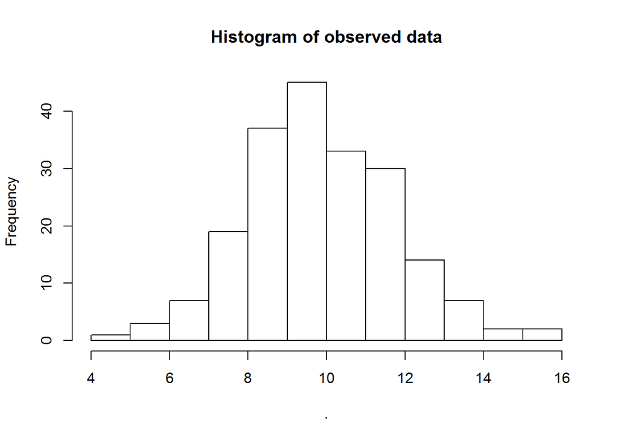

```r
rnorm(n=200,m=10,sd=2) %>% hist(main="Histogram of observed data")
```

```r
x.norm<-rnorm(n=200,m=10,sd=2)
```

We can estimate frequency density using density()and plot()to plot the graphic

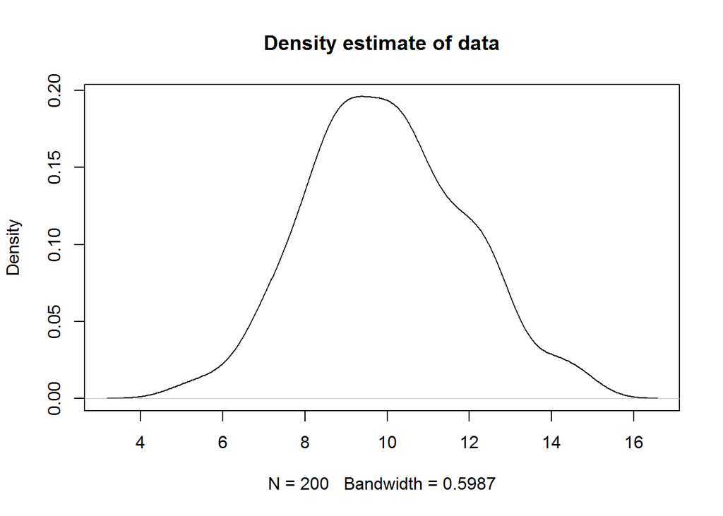

```r
plot(density(x.norm),main="Density estimate of data")
```

R allows to compute the empirical cumulative distribution function by ecdf()

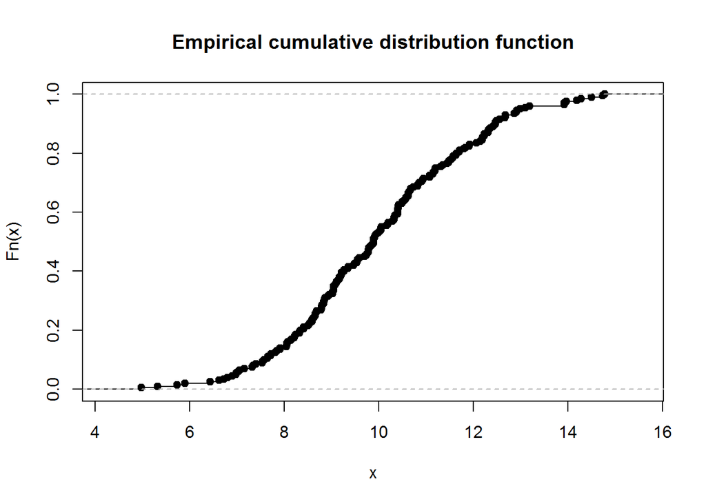

```r
plot(ecdf(x.norm),main='Empirical cumulative distribution function')
```

- A Quantile-Quantile (Q-Q) plot is a scatter plot comparing the fitted and empirical distributions in terms of the dimensional values of the variable (i.e., empirical quantiles). It is a graphical technique for determining if a data set come from a known population. **In this plot on the y-axis we have empirical quantiles on the x-axis we have the ones got by the theorical model**.
- A 45-degree reference line is also plotted. **If the empirical data come from the population with the choosen distribution, the points should fall approximately along this reference line**.

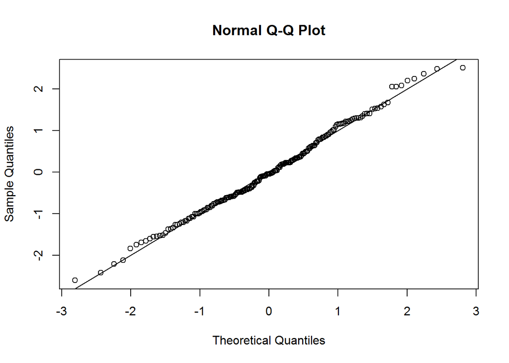

```r
z.norm<-(x.norm-mean(x.norm))/sd(x.norm) ## standardized data
qqnorm(z.norm) ## drawing the QQplot
abline(0,1) ## drawing a 45-degree reference line
```

If data differ from a normal distribution (i.e. data belonging from a Weibull pdf) we can use qqplot()in this way.

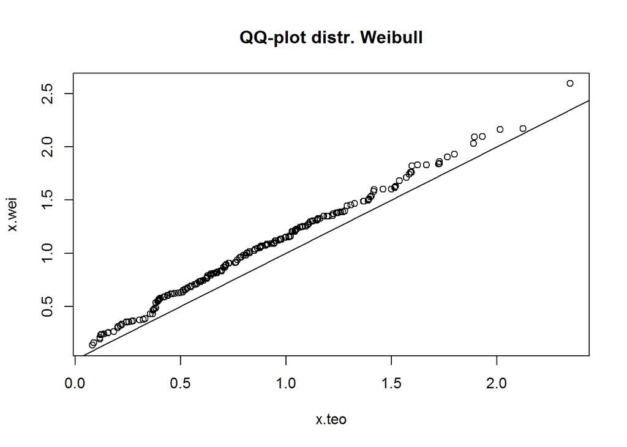

```r
x.wei<-rweibull(n=200,shape=2.1,scale=1.1) ## sampling from a Weibull distribution with parameters shape=2.1 and scale=1.1
x.teo<-rweibull(n=200,shape=2, scale=1) ## theorical quantiles from a Weibull population with known paramters shape=2 e scale=1
qqplot(x.teo,x.wei,main="QQ-plot distr. Weibull") ## QQ-plot
abline(0,1) ## a 45-degree reference line is plotted
```